# Report.R

```r
#57 rows have 2 missing values, 38 rows have 1 missing values.
#Usually when there are missing values in more than one column for a record,
#it's better to ignore that record if one have enough data. Now 38 records have 1 missing values,
#which is just 1% of data. We can simply ignore it as it will just bias our analysis.

#remove NA values
data <- na.omit(data)
```

*EXPLORATORY DATA ANALYSIS*

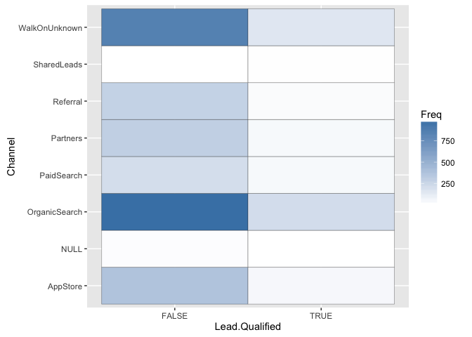

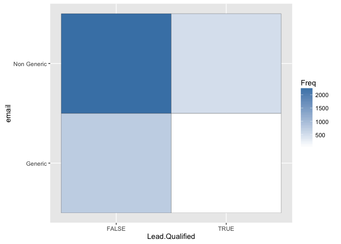

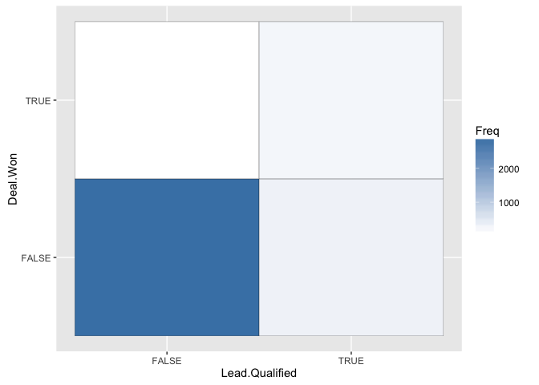

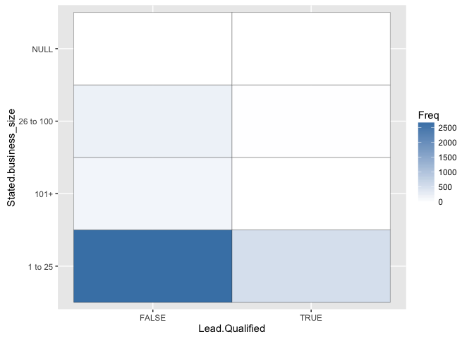

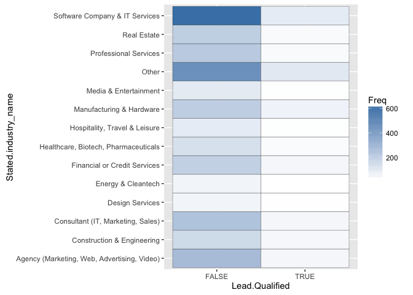

```r
#use function plots to understand the relationship between different variables
plots(y="Lead.Qualified")
```

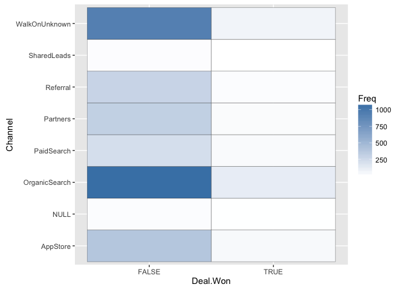

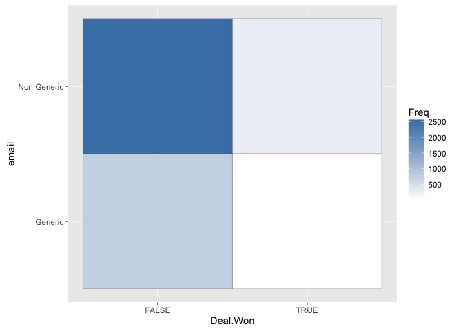

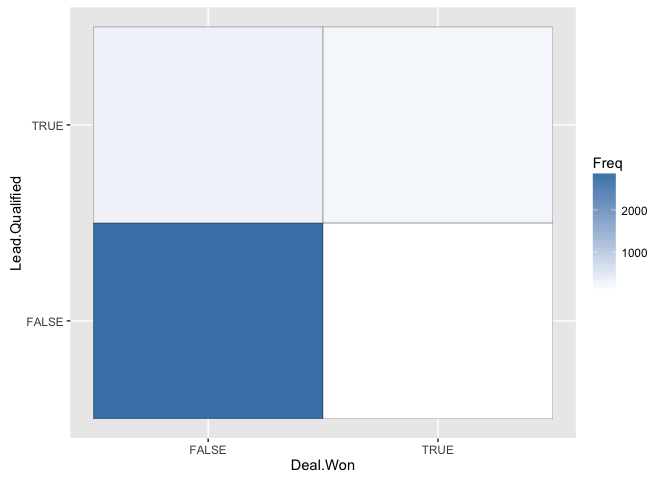

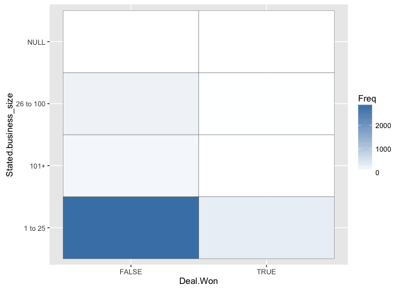

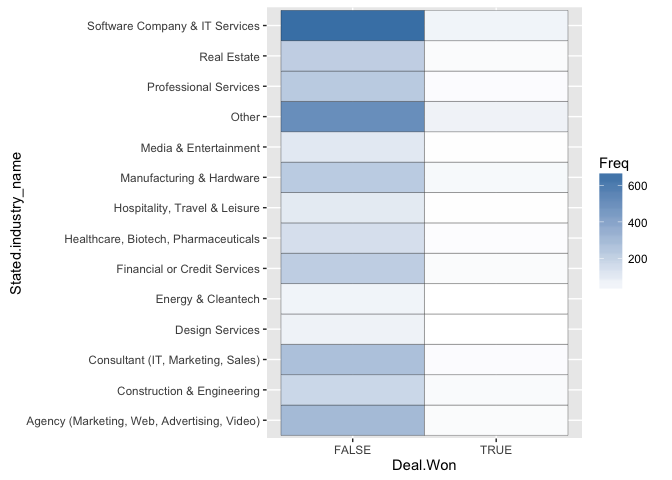

```r
plots(y="Deal.Won")
```

```r
df <- as.data.frame(table(data$Lead.Qualified, data$Deal.Won))
names(df) <- c("Lead.Qualified", "Deal.Won", "Freq")
```

**Table showing how many qualified leads gets converted to deals won**

```r
df
```

```
##   Lead.Qualified Deal.Won Freq
## 1          FALSE    FALSE 2961
## 2           TRUE    FALSE  308
## 3          FALSE     TRUE   79
## 4           TRUE     TRUE  238
```

**Qualified Leads are dependent on variables Channel,email ,Stated.businesssize, and Stated.industryname**  
**Deals Won are dependent on variables Leads qualified, Channel,email ,Stated.businesssize, and Stated.industryname**

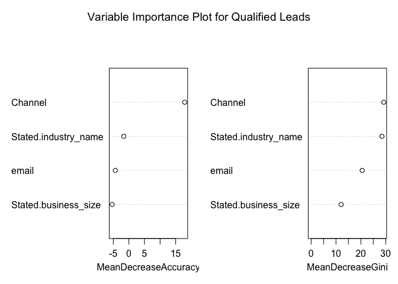

```r
#find the most important variables affecting Qualified Leads and Lead won using random forests
model_rf <- randomForest(Lead.Qualified ~ Channel+ email + Stated.business_size + Stated.industry_name, data=data, importance=TRUE, ntree=500)
varImpPlot(model_rf, main="Variable Importance Plot for Qualified Leads")
```

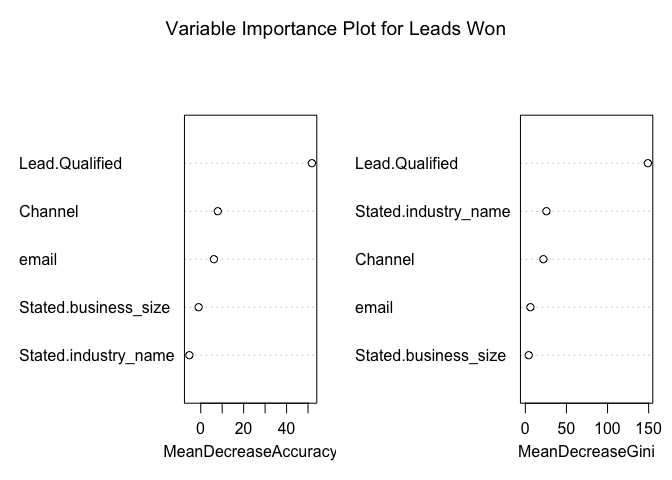

```r
model_rf <- randomForest(Deal.Won ~ Lead.Qualified + Channel+ email + Stated.business_size + Stated.industry_name, data=data, importance=TRUE, ntree=500)
varImpPlot(model_rf, main="Variable Importance Plot for Leads Won")
```

**PREDICTION ON IMBALANCED DATA**  
**Logistic Regression is used for predicting Qualified Leads and Leads Won using 5-fold cross validation**

```r
nfolds <- 5
case.folds <- rep(1:nfolds,length.out=nrow(data))
# divide the cases as evenly as possible
case.folds <- sample(case.folds)

varsLeadQual <- c("Channel", "email", "Stated.business_size", "Stated.industry_name")
yLeadQual <- "Lead.Qualified"
varsDealsWon <- c("Lead.Qualified","Channel", "email", "Stated.business_size", "Stated.industry_name")
yDealsWon <- "Deal.Won"


accTrainQualLeads <- list()
accTestQualLeads <- list()
accTrainLeadsWon <- list()
accTestLeadsWon <- list()

for(fold in 1:nfolds)
{
  train <- data[case.folds!=fold,]
  test <- data[case.folds==fold, ]

  #using logistic regression model
  ############## QUALIFIED LEADS ############################
  #predict training data
  predTrain_QualLeads <- fit_logit(train, vars = varsLeadQual, yColumn = yLeadQual, train)
  #training accuracy
  accTrainQualLeads[[fold]] <- accuracyStats(predTrain_QualLeads, train$Lead.Qualified)

  #predict test data
  predTest_QualLeads <- fit_logit(train, vars = varsLeadQual, yColumn = yLeadQual, test)
  #test accuracy metrics
  accTestQualLeads[[fold]] <- accuracyStats(predTest_QualLeads, test$Lead.Qualified)

  ############# LEADS WON ##################################
  #predict training data and accuracy stats
  predTrain_LeadsWon <- fit_logit(train, vars = varsDealsWon, yColumn = yDealsWon, train)
  accTrainLeadsWon[[fold]] <- accuracyStats(predTrain_LeadsWon, train$Deal.Won)

  #predict test data and accuracy stats
  predTest_LeadsWon <- fit_logit(train, vars = varsDealsWon, yColumn = yDealsWon, test)
  accTestLeadsWon[[fold]] <- accuracyStats(predTest_LeadsWon, test$Deal.Won)
}

Stats_QualLeadsTrain <- Reduce( function(x,y) mapply("+",x,y), accTrainQualLeads)/length(accTrainQualLeads)
Stats_QualLeadsTest <- Reduce( function(x,y) mapply("+",x,y), accTestQualLeads)/length(accTestQualLeads)
```

**Logistic Regression**  
**Performance metrics for Qualified Leads for both train and test data on imbalanced dataset**

```r
rbind(Stats_QualLeadsTrain, Stats_QualLeadsTest)
```

```
##                      precision     recall  accuracy       auc
## Stats_QualLeadsTrain 0.7111888 0.01928443 0.8494844 0.6771966
## Stats_QualLeadsTest  0.8133333 0.01882811 0.8494194 0.6514131
```

```r
Stats_LeadsWonTrain <- Reduce( function(x,y) mapply("+",x,y), accTrainLeadsWon)/length(accTrainLeadsWon)
Stats_LeadsWonTest <- Reduce( function(x,y) mapply("+",x,y), accTestLeadsWon)/length(accTestLeadsWon)
```

**Logistic Regression**  
**Performance metrics for Leads Won for both train and test data on imbalanced dataset**

```r
rbind(Stats_LeadsWonTrain, Stats_LeadsWonTest)
```

```
##                     precision    recall  accuracy       auc
## Stats_LeadsWonTrain 0.5481818 0.2556330 0.9152957 0.8817269
## Stats_LeadsWonTest  0.4218938 0.2078388 0.9057474 0.8537410
```